# DataVis_homework_to_12_10

AB

2024-10-08

```r
hogwarts <- read_csv("Data/hogwarts_2024.csv")
hogwarts |> head()
```

```
## # A tibble: 6 × 60
##      id house    course sex   wandCore bloodStatus result Defence against the …¹
##   <dbl> <chr>     <dbl> <chr> <chr>    <chr>        <dbl>                  <dbl>
## 1     1 Ravencl…      4 fema… unicorn… half-blood      94                     73
## 2     2 Hufflep…      5 male  phoenix… half-blood      33                     38
## 3     3 Ravencl…      4 fema… dragon … half-blood     137                     52
## 4     4 Hufflep…      2 male  phoenix… half-blood      27                     50
## 5     5 Hufflep…      2 fema… phoenix… half-blood      67                     47
## 6     6 Gryffin…      6 male  phoenix… muggle-born    126                     44
## # ℹ abbreviated name: ¹`Defence against the dark arts exam`
## # ℹ 52 more variables: `Flying exam` <dbl>, `Astronomy exam` <dbl>,
## #   `Herbology exam` <dbl>, `Divinations exam` <dbl>, `Charms exam` <dbl>,
## #   `History of magic exam` <dbl>, `Arithmancy exam` <dbl>,
## #   `Care of magical creatures exam` <dbl>, `Muggle studies exam` <dbl>,
## #   `Study of ancient runes exam` <dbl>, `Transfiguration exam` <dbl>,
## #   `Potions exam` <dbl>, week_1 <dbl>, week_2 <dbl>, week_3 <dbl>, …
```

```r
hogwarts <- hogwarts |> mutate(
  across(c(house, course, sex, wandCore, bloodStatus), ~ as.factor(.x)))

  glimpse(hogwarts)
```

```
## Rows: 560
## Columns: 60
## $ id                                   <dbl> 1, 2, 3, 4, 5, 6, 7, 8, 9, 10, 11…
## $ house                                <fct> Ravenclaw, Hufflepuff, Ravenclaw,…
## $ course                               <fct> 4, 5, 4, 2, 2, 6, 7, 5, 2, 3, 7, …
## $ sex                                  <fct> female, male, female, male, femal…
## $ wandCore                             <fct> unicorn hair, phoenix feather, dr…
## $ bloodStatus                          <fct> half-blood, half-blood, half-bloo…
## $ result                               <dbl> 94, 33, 137, 27, 67, 126, 63, 7, …
## $ `Defence against the dark arts exam` <dbl> 73, 38, 52, 50, 47, 44, 51, 47, 2…
## $ `Flying exam`                        <dbl> 33, 36, 73, 42, 41, 52, 34, 34, 2…
## $ `Astronomy exam`                     <dbl> 57, 45, 66, 49, 57, 59, 58, 37, 5…
## $ `Herbology exam`                     <dbl> 73, 50, 62, 39, 38, 46, 59, 23, 2…
## $ `Divinations exam`                   <dbl> 66, 54, 72, 42, 47, 49, 42, 38, 1…
## $ `Charms exam`                        <dbl> 60, 70, 77, 46, 35, 55, 86, 20, 4…
```

[output cut: 47 more lines]

```r
theme_custom <- theme(
    panel.background = element_rect(fill = "white"),
    plot.title = element_text(size = 30, hjust = 0.5),
    plot.subtitle = element_text(size = 25, hjust = 0.5),
    strip.text = element_text(size = 16),
    axis.text = element_text(size = 12),
    axis.title = element_text(size = 16),
    legend.title = element_text(size = 16),
    legend.text = element_text(size = 12)
  )

se <- function(x){
  sd(x, na.rm=TRUE)/sqrt(length(x))
}
```

#Диаграммы рассеяния(скаттерплоты)

##1

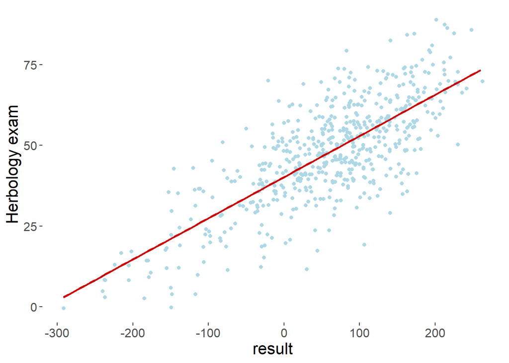

```r
hogwarts %>%
  ggplot()+
geom_point(aes(x = `result`,
               y = `Herbology exam`),
           colour = "lightblue",
           position = position_jitter(width = 3, height = 3))+
  geom_smooth(aes(x = `result`,
               y = `Herbology exam`),
              method = "lm",
              se = FALSE,
              colour = "red3")+
  theme_custom
```

Имеется ассоциация между суммарным баллом и баллом за экзамен по травологии. Из графика сделует, что те студенты, которые имели большой общий балл, сдавали экзамен по травологии на высокий балл, и наоборот, те студенты, которые имели небольшой общий балл, получали низкий балл по травологии. Большая часть студентов имеет 0-150 баллов за год и 25-70 баллов по травологии.

##2

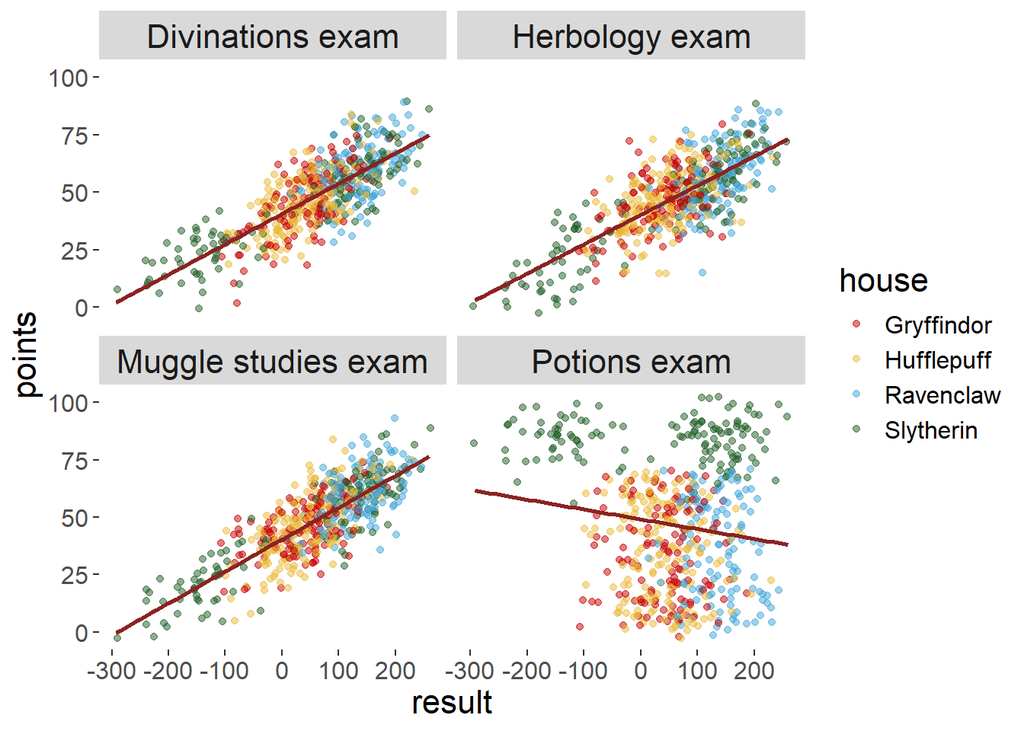

```r
new_hogwarts <- hogwarts %>%
  select(`id`,`result`, `house`, `Herbology exam`, `Muggle studies exam`, `Divinations exam`, `Potions exam`) %>%
  pivot_longer(!c(id, result, house), names_to = "exam", values_to = "points")

 new_hogwarts %>%
  ggplot()+
geom_point(aes(x = `result`,
            y = `points`,
            colour = house),
           alpha = 0.5,
           position = position_jitter(width = 3, height = 3))+
  scale_color_manual(values = c("Gryffindor" = "#C50000",
                               "Hufflepuff" = "#ECB939",
                               "Ravenclaw" = "#41A6D9",
                               "Slytherin" = "#1F5D25"))+
  geom_smooth(aes(x = `result`,
               y = `points`),
              method = "lm",
              se = FALSE,
              colour = "brown4") +
   facet_wrap(vars(exam))+
  theme_custom
```

Существует ассоциация между общим баллом студентов и баллом по прорицаниям, травологии, маггловедению. По прорицаниям, травологии и маггловедению студенты, которые имели большой общий балл, сдавали данные экзамены на высокий балл и наоборот, те студенты, которые имели небольшой общий балл, получали низкий балл по экзаменам. Студенты когтеврана в основном лучше сдают данные экзамены, получают высший балл и получают больший общий балл, чем студенты других факультетов. Среди студентов слизерина больше всего плохо сдающих экзамены и набирающих меньший балл студентов, однако те студенты слизерина, которые набирают большой общий балл, хорошо сдают данные экзамены и получают высший балл. Студенты гриффиндора и пуффендуя набирают в основном средний общий балл и средний балл по экзаменам. По экзамену по зельеваренью ассоциация менее выражена и визуально сложно определить значима ли она. Также этот график демонтрирует, что студенты слизерина сдают экзамен по зельеваренью лучше остальных факультетов (единственные, кто набирает высший балл), причем высокий балл получают как студенты, которые получили низкий общий балл, так и те, кто получил высокий общий балл. Студенты остальных факультетов не получают высший балл по зельеваренью. Также 100 баллов студенты получают только по зельеваренью, по остальным экзаменам 100 баллов никто не получает.

##3

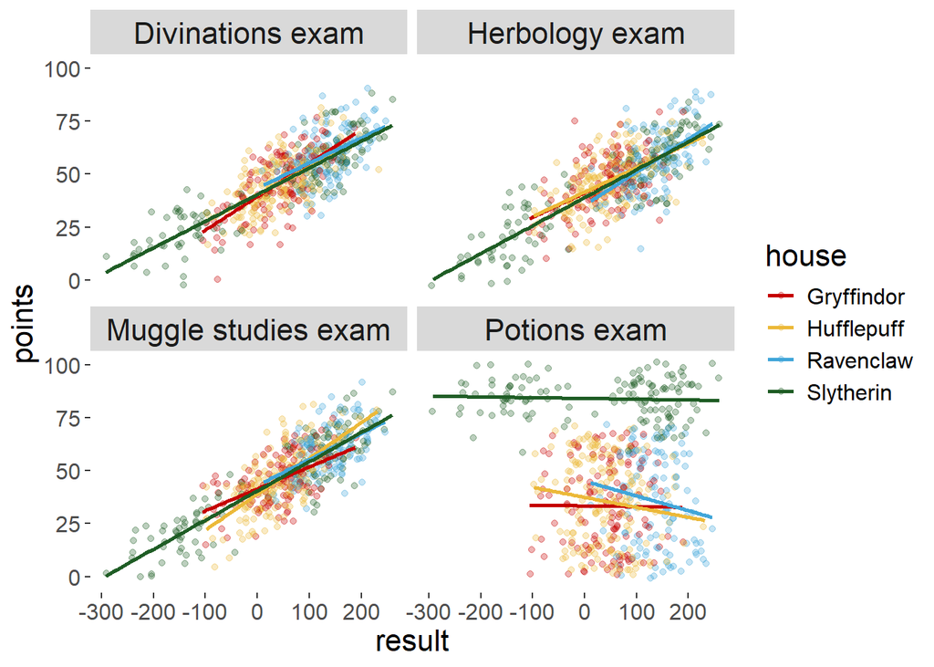

```r
new_hogwarts %>%
  ggplot()+
geom_point(aes(x = `result`,
            y = `points`,
            colour = house),
           alpha = 0.3,
           position = position_jitter(width = 3, height = 3))+
  scale_color_manual(values = c("Gryffindor" = "#C50000",
                               "Hufflepuff" = "#ECB939",
                               "Ravenclaw" = "#41A6D9",
                               "Slytherin" = "#1F5D25"))+
  geom_smooth(aes(x = `result`,
               y = `points`,
               colour = house),
              method = "lm",
              se = FALSE) +
   facet_wrap(vars(exam))+
  theme_custom
```

#geom_col и вещи вокруг него

##1

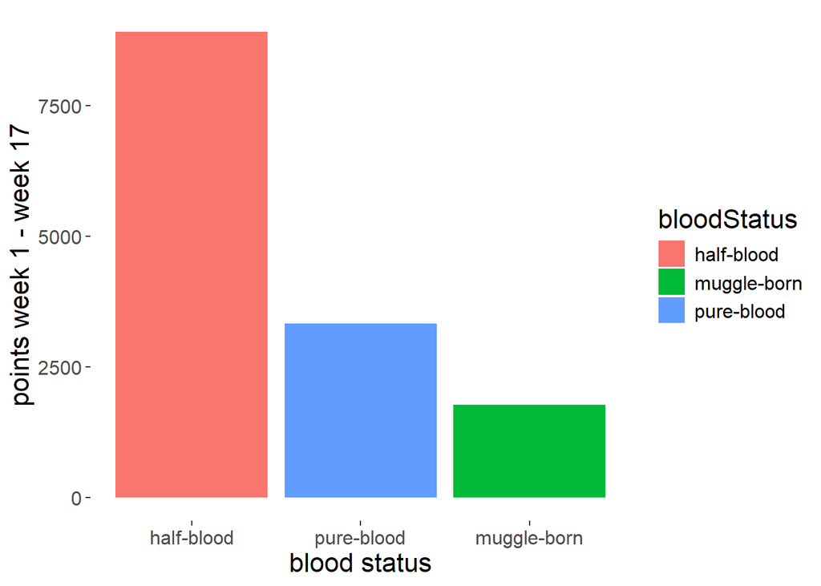

```r
#glimpse(hogwarts)
#colnames(hogwarts)
bloodStatus_points_week1_17 <- hogwarts %>%
  rowwise() %>%
  mutate(result_week_1_17 = sum(c(`week_1`, `week_2`,`week_3`,`week_4`,`week_5`,`week_6`,`week_7`,`week_8`,`week_9`,`week_10`,`week_11`,`week_12`,`week_13`,`week_14`,`week_15`,`week_16`,`week_17`))) %>%
  group_by(bloodStatus) %>%
  summarise(bloodStatus_points = sum(result_week_1_17))

bloodStatus_points_week1_17 %>%
  ggplot()+
  geom_col(aes(x = fct_reorder(bloodStatus,bloodStatus_points, .desc = TRUE),
               y = bloodStatus_points,
               fill = bloodStatus))+
  xlab(label = "blood status")+
  ylab(label = "points week 1 - week 17")+
  theme_custom
```

Гипотеза: полукровные студенты, имея генетическую основу для магии и осознавая свой статус больше стараются и получают высокиt баллы. Чистокровные студенты имеют магические способности, но зная, что они чистокровные меньше стараются, но преуспевают в учебе. Маггло-рожденные имеют меньший генетический вклад в магические способности, поэтому их старания не ведут к лучшей успеваемости.

##2

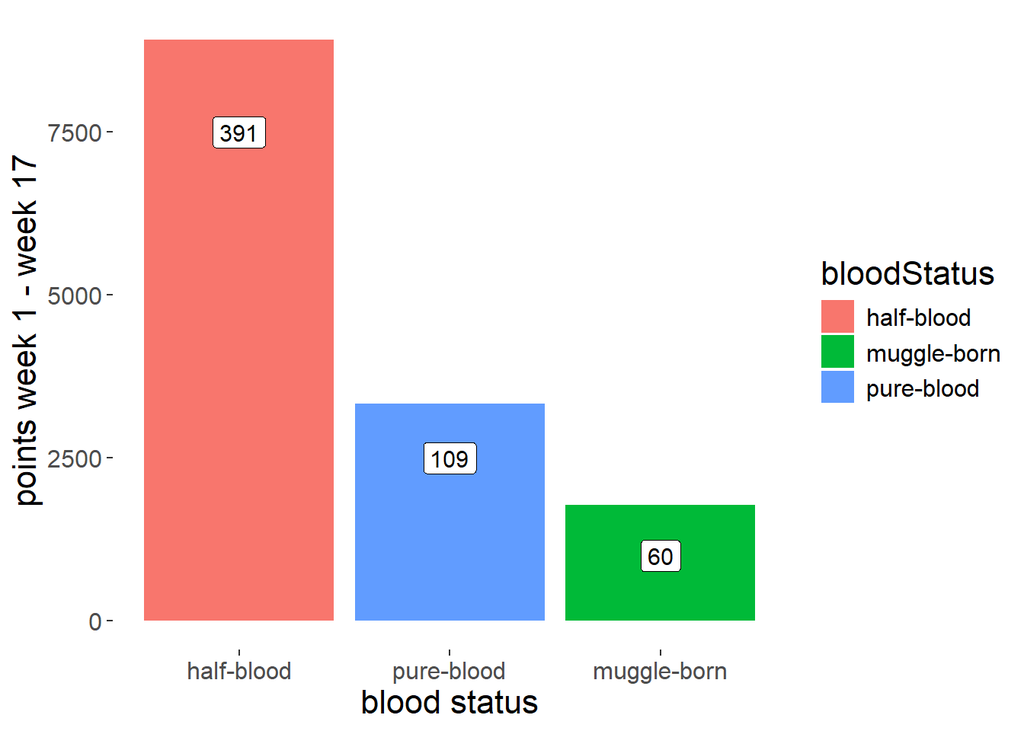

```r
hogwarts1 <- hogwarts %>%
  rowwise() %>%
  mutate(result_week_1_17 = sum(c(`week_1`, `week_2`,`week_3`,`week_4`,`week_5`,`week_6`,`week_7`,`week_8`,`week_9`,`week_10`,`week_11`,`week_12`,`week_13`,`week_14`,`week_15`,`week_16`,`week_17`))) %>%
  group_by(bloodStatus) %>%
  summarise(student_count = length(bloodStatus))

 hogwarts2 <-  hogwarts %>%
  rowwise() %>%
  mutate(result_week_1_17 = sum(c(`week_1`, `week_2`,`week_3`,`week_4`,`week_5`,`week_6`,`week_7`,`week_8`,`week_9`,`week_10`,`week_11`,`week_12`,`week_13`,`week_14`,`week_15`,`week_16`,`week_17`))) %>%
  group_by(bloodStatus) %>%
  summarise(bloodStatus_points = sum(result_week_1_17)) %>%
   select(bloodStatus_points)

newbloodStatus_points_week1_17 <- hogwarts1 %>% bind_cols(hogwarts2)

newbloodStatus_points_week1_17 %>%
  ggplot()+
  geom_col(aes(x = fct_reorder(bloodStatus,bloodStatus_points, .desc = TRUE),
               y = bloodStatus_points,
               fill = bloodStatus))+
  xlab(label = "blood status")+
  ylab(label = "points week 1 - week 17")+
  geom_label(aes(x = 1,
                 y = 7500,
               label = 391),
             size = 4)+
  geom_label(aes(x = 2,
                 y = 2500,
               label = 109),
             size = 4)+
  geom_label(aes(x = 3,
                 y = 1000,
               label = 60),
             size = 4)+
  theme_custom
```

Исходя из графика можно сделать вывод, что полукровные студенты получили больше баллов за 17 недель, так как их количество больше, чем всех остальных студентов, а маггло-рожденных меньше всех. Такая интерпретация не совпадает с гипотезой, выдвинутой в 1 задании.

##3

```r
sex_bloodStatus_points_week1_17 <- hogwarts %>%
  rowwise() %>%
  mutate(result_week_1_17 = sum(c(`week_1`, `week_2`,`week_3`,`week_4`,`week_5`,`week_6`,`week_7`,`week_8`,`week_9`,`week_10`,`week_11`,`week_12`,`week_13`,`week_14`,`week_15`,`week_16`,`week_17`))) %>%
  ungroup()%>%
  group_by(bloodStatus, sex) %>%
  summarise(bloodStatus_points = sum(result_week_1_17)) %>%
  mutate(sex_bloodStatus = paste0(sex, " ", bloodStatus))
```

```r
#glimpse(sex_bloodStatus_points_week1_17)

sex_bloodStatus_points_week1_17_plot <- sex_bloodStatus_points_week1_17 %>%
  ggplot()+
  geom_col(aes(x = bloodStatus_points,
               y = fct_reorder(sex_bloodStatus,bloodStatus_points, .desc = FALSE),
               fill = bloodStatus))+
  labs(title = "Распределение очков за 1-17 нед. в зависимости от происхождения и пола",
    x = "points week 1 - week 17",
    y = "sex and blood status")+
  #limits=c(0, max(df$value) + 40), expand = c(0, 0))
  scale_x_continuous(limits= c(-500, 10000), breaks = seq(0,10000,1000))+
  #xlim(-500,10000)+
  geom_text(aes(y = fct_reorder(sex_bloodStatus, bloodStatus_points, .desc = FALSE),
               x = bloodStatus_points,
               label = bloodStatus_points),
            size = 4,
            hjust = -0.2)+
  theme(panel.background = element_rect(fill = "white"),
    plot.title = element_text(size = 12, hjust = 0.5),
    strip.text = element_text(size = 16),
    axis.text = element_text(size = 12),
    axis.title = element_text(size = 16),
    legend.title = element_text(size = 16),
    legend.text = element_text(size = 12))

ggsave("sex_and_bloodstatus_barplot.png", sex_bloodStatus_points_week1_17_plot, width = 8, height = 6, units = "in", dpi = 300)
```

##4

Функция переворачивает оси графиков. Удобно использовать её, когда мы уже сделали график по определенным осям, а потом поняли, что график может выглядеть лучше, если его перевернуть, при этом не надо менять вручную оси. Минусы заключаются в упорядочивании при переворачивании графика, иногда может изменяться порядок переменных на графике и не соотвествовать порядку переменных из изначального графика.

#Разное

##1

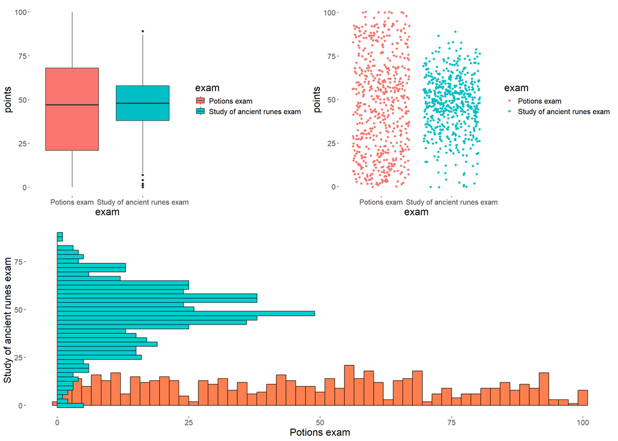

```r
#glimpse(hogwarts)
potion_runes_boxplot <- hogwarts %>%
  select(`id`, `Potions exam`, `Study of ancient runes exam`) %>%
  pivot_longer(!`id`, names_to = "exam", values_to = "points") %>%
  ggplot()+
  geom_boxplot(aes(x = exam,
                   y = points,
                   fill = exam))+
  theme_custom
  #theme(
    #legend.position = c(0.2, 0.8),
        #legend.background = element_rect(fill = "white"))

potion_runes_jitter <- hogwarts %>%
  select(`id`, `Potions exam`, `Study of ancient runes exam`) %>%
  pivot_longer(!`id`, names_to = "exam", values_to = "points") %>%
  ggplot()+
  geom_jitter(aes (x = exam,
                   y = points,
                   colour = exam))+
  theme_custom

potion_runes_hist <- hogwarts %>%
  ggplot()+
  geom_histogram(aes(x = `Potions exam`),
                 fill = "coral",
                 colour = "black",
                 bins = 55)+
  geom_histogram(aes(y = `Study of ancient runes exam`),
                 fill = "cyan3",
                 colour = "black",
                 bins = 40)+
  theme_custom

ggarrange(ggarrange(potion_runes_boxplot, potion_runes_jitter, ncol = 2),
          potion_runes_hist,
          nrow = 2)
```

##2 Визуализируйте средний балл по зельеварению студентов с различным происхождением. Вы вольны добавить дополнительные детали и информацию на график. Проинтерпретируйте результат. Как вы думаете, почему он именно такой? Если у вас есть гипотеза, проиллюстрируйте ее еще одним графиком (или графиками). Объедините их при помощи ggarrange. (по 1 б. за первый и график и правильную интерпретацию с подтверждением в виде второго графика и текстовой аргументации). Измените порядок ваших фигур на первом графике слева направо следующим образом: маглорожденные,, чистокровные, полукровки. Скорректируйте название оси. Если у вас возникают сложности, обратитесь к шпаргалке по пакету forcats от posit.

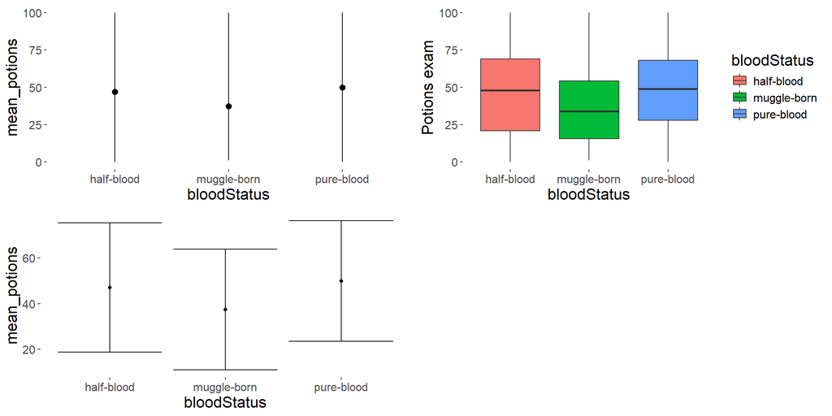

```r
mean_div <- hogwarts %>%
  group_by(bloodStatus) %>%
  summarise(mean_div = mean(`Divinations exam`) %>% round(2),
            min = (min(`Divinations exam`) %>% round(2)),
            max = (max(`Divinations exam`) %>% round(2))) %>%
  ggplot()+
  geom_pointrange(aes(x = bloodStatus,
                   y = mean_div,
                   ymin = min,
                   ymax = max))+
  theme_custom

mean_potions_boxplot <- hogwarts %>%
  ggplot()+
  geom_boxplot(aes(x = bloodStatus,
                   y = `Potions exam`,
                   fill = bloodStatus))+
  theme_custom

mean_potions_error <- hogwarts %>%
  group_by(bloodStatus) %>%
  summarise(mean_potions = mean(`Potions exam`) %>% round(2),
            min = (min(`Potions exam`) %>% round(2)),
            max = (max(`Potions exam`) %>% round(2)),
            sd = sd(`Potions exam`)) %>%
  ggplot(aes(x = bloodStatus,
             y = mean_potions))+
  geom_point()+
  geom_errorbar(aes(ymin = mean_potions - `sd`, ymax = mean_potions + `sd`))+
  theme_custom

mean_potions <- hogwarts %>%
  group_by(bloodStatus) %>%
  summarise(mean_potions = mean(`Potions exam`) %>% round(2),
            min = (min(`Potions exam`) %>% round(2)),
            max = (max(`Potions exam`) %>% round(2))) %>%
  ggplot()+
  geom_pointrange(aes(x = bloodStatus,
                   y = mean_potions,
                   ymin = min,
                   ymax = max))+
  theme_custom

mean_herb <- hogwarts %>%
  group_by(bloodStatus) %>%
  summarise(mean_herb = mean(`Herbology exam`) %>% round(2),
            min = (min(`Herbology exam`) %>% round(2)),
            max = (max(`Herbology exam`) %>% round(2))) %>%
  ggplot()+
  geom_pointrange(aes(x = bloodStatus,
                   y = mean_herb,
                   ymin = min,
                   ymax = max))+
  theme_custom

mean_muggle <- hogwarts %>%
  group_by(bloodStatus) %>%
  summarise(mean_muggle = mean(`Muggle studies exam`) %>% round(2),
            min = (min(`Muggle studies exam`) %>% round(2)),
            max = (max(`Muggle studies exam`) %>% round(2))) %>%
  ggplot()+
  geom_pointrange(aes(x = bloodStatus,
                   y = mean_muggle,
                   ymin = min,
                   ymax = max))+
 theme_custom

mean_transf <- hogwarts %>%
  group_by(bloodStatus) %>%
  summarise(mean_transf = mean(`Transfiguration exam`) %>% round(2),
            min = (min(`Transfiguration exam`) %>% round(2)),
            max = (max(`Transfiguration exam`) %>% round(2))) %>%
  ggplot()+
  geom_pointrange(aes(x = bloodStatus,
                   y = mean_transf,
                   ymin = min,
                   ymax = max))+
  theme_custom

ggarrange(mean_potions, mean_potions_boxplot, mean_potions_error)
```

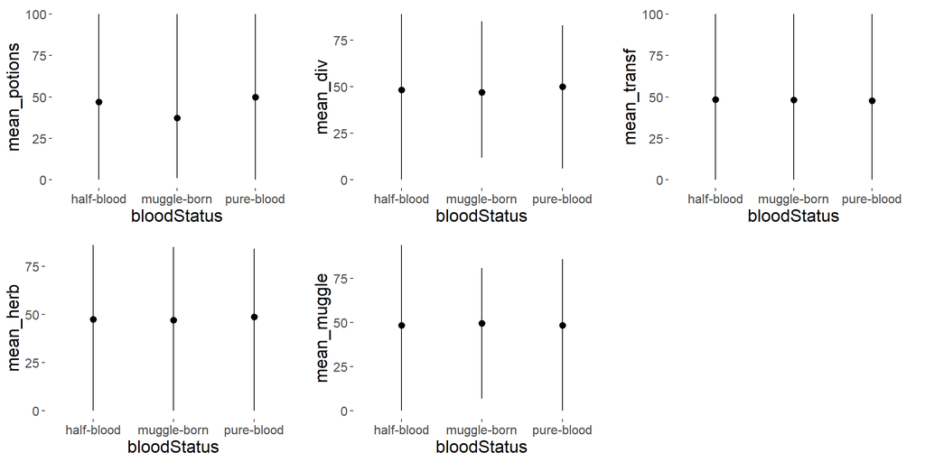

```r
ggarrange(mean_potions, mean_div, mean_transf, mean_herb, mean_muggle)
```

Средний балл по зельеваренью у студентов разного происхождения находится примерно на одном уровне, однако у маггло-рожденных балл всё-таки ниже, чем у остальных. Гипотеза: это дискриминация маггло-рожденных студентов со стороны преподавателя зельеваренья. Если взять для примера другие экзамены, данные студенты имеют такой же средний балл, как остальные студенты. Проанализируем средние баллы студентов разных происхождений по другим экзаменам. На графиках видно, что по остальным экзаменам средние баллы студентов почти равны. Таким образом имеет место дискриминация маггло-рожденных студентов на экзамене по зельеваренью.

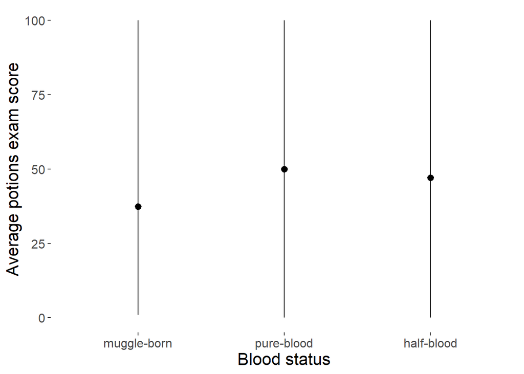

```r
 hogwarts %>%
  group_by(bloodStatus) %>%
  summarise(mean_potions = mean(`Potions exam`) %>% round(2),
            min = (min(`Potions exam`) %>% round(2)),
            max = (max(`Potions exam`) %>% round(2))) %>%
  ggplot(aes(x = bloodStatus, y = mean_potions))+
  geom_pointrange(aes(x = factor(bloodStatus, levels = c("muggle-born", "pure-blood", "half-blood")),
                   y = mean_potions,
                   ymin = min,
                   ymax = max))+
   xlab("Blood status")+
   ylab("Average potions exam score")+
  theme_custom
```